# Exploratory Analysis of NHS Service Utilisation, Missed Appointments, and Social Media Insights

## 📝 Make recommendations to the NHS based on data from Aug 2021 onwards

**Use the 'appointments_regional.csv' DataFrame to support reccomendations**

```python
# Prepare your workstation.
# Load the appointments_regional.csv file.
ar = pd.read_csv('appointments_regional.csv')

# View the DataFrame.
ar.head()
```

|  | icb_ons_code | appointment_month | appointment_status | hcp_type | appointment_mode | time_between_book_and_appointment | count_of_appointments |
| --- | --- | --- | --- | --- | --- | --- | --- |
| 0 | E54000034 | 2020-01 | Attended | GP | Face-to-Face | 1 Day | 8107 |
| 1 | E54000034 | 2020-01 | Attended | GP | Face-to-Face | 15 to 21 Days | 6791 |
| 2 | E54000034 | 2020-01 | Attended | GP | Face-to-Face | 2 to 7 Days | 20686 |
| 3 | E54000034 | 2020-01 | Attended | GP | Face-to-Face | 22 to 28 Days | 4268 |
| 4 | E54000034 | 2020-01 | Attended | GP | Face-to-Face | 8 to 14 Days | 11971 |

```python
# Print the min and max dates.
print(f"The earliest date in the AR dataset is {ar_min_date}.")
print(f"The latest date in the AR dataset is {ar_max_date}")
```

```
The earliest date in the AR dataset is 2020-01.
The latest date in the AR dataset is 2022-06
```

```python
# Filter the data set to only look at data from 2021-08 onwards.
ar_filtered = ar[ar['appointment_month'] >= '2021-08']

print(f"The new earliest date in the AR dataset is {ar_filtered['appointment_month'].min()}.")
print(f"The new latest date in the AR dataset is {ar_filtered['appointment_month'].max()}.")
```

```
The new earliest date in the AR dataset is 2021-08.
The new latest date in the AR dataset is 2022-06.
```

### ❓ Should the NHS start looking at increasing staff levels?

```python
# Create an aggregated data set to review the different features.
ar_agg = (
    ar_filtered.groupby(['appointment_month', 'hcp_type','appointment_status','appointment_mode',
                'time_between_book_and_appointment'])
    .agg({'count_of_appointments': 'sum'})
    .reset_index()
)

# View the DataFrame.
ar_agg.head()
```

|  | appointment_month | hcp_type | appointment_status | appointment_mode | time_between_book_and_appointment | count_of_appointments |
| --- | --- | --- | --- | --- | --- | --- |
| 0 | 2021-08 | GP | Attended | Face-to-Face | 1 Day | 507835 |
| 1 | 2021-08 | GP | Attended | Face-to-Face | 15 to 21 Days | 194726 |
| 2 | 2021-08 | GP | Attended | Face-to-Face | 2 to 7 Days | 959486 |
| 3 | 2021-08 | GP | Attended | Face-to-Face | 22 to 28 Days | 102111 |
| 4 | 2021-08 | GP | Attended | Face-to-Face | 8 to 14 Days | 398772 |

```python
# Determine the total number of appointments per month.
ar_df = (
    ar_agg.groupby('appointment_month')['count_of_appointments']
    .sum()
    .reset_index()
)

# Add a utilisation column to the ar_df DataFrame
ar_df['daily_appts'] = ar_df['count_of_appointments'] / 30
ar_df['utilisation'] = (ar_df['daily_appts'] / 1200000) * 100
ar_df['utilisation'] = ar_df['utilisation'].round(1)

# View the DataFrame.
ar_df.head()
```

|  | appointment_month | count_of_appointments | daily_appts | utilisation |
| --- | --- | --- | --- | --- |
| 0 | 2021-08 | 23852171 | 7.950724e+05 | 66.3 |
| 1 | 2021-09 | 28522501 | 9.507500e+05 | 79.2 |
| 2 | 2021-10 | 30303834 | 1.010128e+06 | 84.2 |
| 3 | 2021-11 | 30405070 | 1.013502e+06 | 84.5 |
| 4 | 2021-12 | 25140776 | 8.380259e+05 | 69.8 |

```python
# Convert the appointment_month to string data type for ease of visualisation.
ar_df['appointment_month'] = ar_df['appointment_month'].astype(str)
ar_df = ar_df.sort_values(by = 'appointment_month')
```

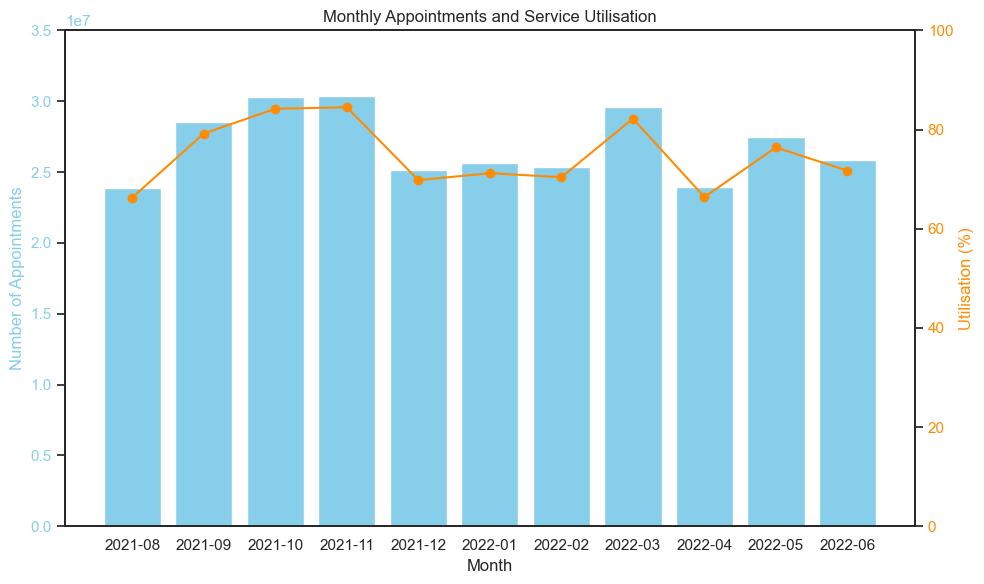

```python
# Plot monthly appointments and service utilisation on one graph

# Set the figure size
fig, ax1 = plt.subplots(figsize=(10, 6))

# Plot bar chart for total appointments
ax1.bar(ar_df['appointment_month'], ar_df['count_of_appointments'], color = 'skyblue', label = 'Appointments')
ax1.set_xlabel('Month')
ax1.set_ylabel('Number of Appointments', color = 'skyblue')
ax1.tick_params(axis = 'y', labelcolor = 'skyblue')
ax1.set_ylim(0, 3.5e7)

# Plot lineplot for utilisation (%)
ax2 = ax1.twinx()
ax2.plot(ar_df['appointment_month'], ar_df['utilisation'], color = 'darkorange', marker = 'o', label = 'Utilisation (%)')
ax2.set_ylabel('Utilisation (%)', color = 'darkorange')
ax2.tick_params(axis = 'y', labelcolor = 'darkorange')
ax2.set_ylim(0,100)


# Title and layout
plt.title('Monthly Appointments and Service Utilisation')
plt.tight_layout()
plt.show()
```

**Number Of Appointments**

```
- Fluctuates, but there are periods of high appointment numbers during the winter season, likely caused by seasonal flu.
```

**Utilisation**

```
- Utilisation remains between 60-85% throughout indicating operation near max capacity.
- Utilisation is frequently around the 80% mark.
```

**Relationship between Number of Appointments and Utilisation**

```
- Increased demand directly translates to higher pressure on existing resources.
- Even during periods of fewer appointments (Apr 2022), utilisation remains relatively high (> 60%)
```

> *Should the NHS increase staff levels?* - **Yes**

```
- Sustained high utilisation means:
    * Risk of burnout and compromised care - Negatively impact a patient's safety.
    * Lack of resilience - little room to handle unexpected events, staff absences or surges in demand.

- Improving staffing leads to:
    * Reduced wait times
    * Improved staff well-being and retention.
    * Enhanced quality of care
    * Greater flexibility to manage fluctuating demand.
```

**Data Limitations**

```
- There is no staff capacity reference so we are limited to conclusively determine if the NHS requires more staff.
```

> 📌 The NHS should start planning to allocate more staff in areas where utilisation is particularly high.

### ❓ How do the healthcare professional types differ over time?

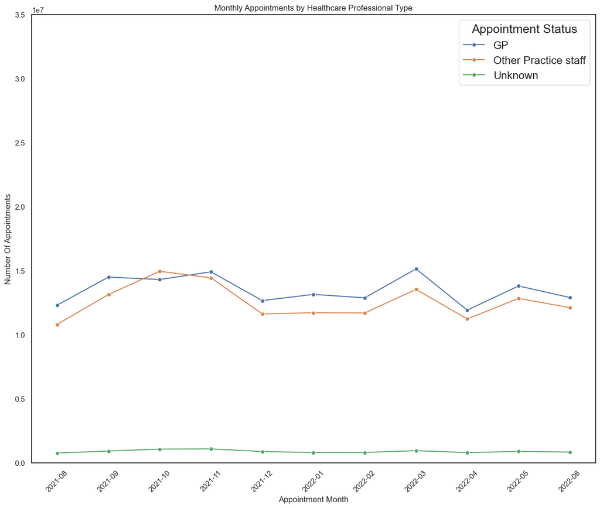

```python
# Create a variable which groups by appointment month and hcp_type
hcp_monthly = (
    ar_agg.groupby(['appointment_month','hcp_type'])['count_of_appointments']
    .sum()
    .reset_index()
)
hcp_monthly.head()

# Create a line plot to answer the question.
sns.lineplot(
    data = hcp_monthly,
    x = 'appointment_month',
    y = 'count_of_appointments',
    hue = 'hcp_type',
    marker = 'o'
)

plt.title('Monthly Appointments by Healthcare Professional Type')
plt.xlabel('Appointment Month')
plt.ylabel('Number Of Appointments')
plt.xticks(rotation = 45)
plt.legend(title = 'HCP Type')
plt.legend(title='Appointment Status', fontsize=16, title_fontsize=18)
plt.ylim(0, 3.5e7)
plt.show()
```

**GPs (blue line)**

[output not shown]

**Other Practice Staff (orange line)**

```
- Performed slightly fewer appointments than GPs.
- The gap between GPs and Other Practice Staff begins to close indicating more of a reliance on these staff to carry out activities.
```

**Unknown (green line)**

```
- Makes up a very small portion of appointments.
- Consistent low number of 'Unknown' appointments indicates good data categorization.
```

> *Do healthcare professionals differ over time?* - **Yes**

The unknown HCPs account for a very low number of appointments which indicates positive completion of records.

### ❓ Are there significant changes in whether or not visits are attended?

```python
# Create a variable which groups by appointment month and appointment status
status_monthly = (
    ar_agg.groupby(['appointment_month','appointment_status'])['count_of_appointments']
    .sum()
    .reset_index()
)
```

```python
# Add a column to show the percentage of each status relative to the total appointments for the month

# Calculate the monthly total appointments
status_monthly_totals = (
    status_monthly.groupby('appointment_month')['count_of_appointments'].transform('sum')
)

# Calculate percentages
status_monthly['percentage'] = (status_monthly['count_of_appointments'] / status_monthly_totals) * 100
status_monthly['percentage'] = status_monthly['percentage'].round(1)
```

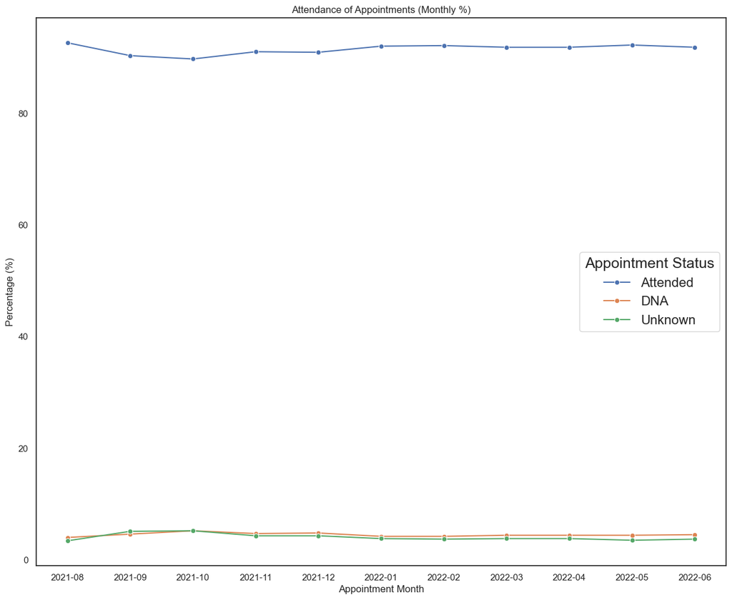

```python
# Create a line plot to show the percentage of appointments attended, DNA or Unknown.
# Plot percentage trends using seaborn (left y-axis)
sns.lineplot(
    data = status_monthly,
    x = 'appointment_month',
    y = 'percentage',
    hue = 'appointment_status',
    marker = 'o'
)

plt.title('Attendance of Appointments (Monthly %)')
plt.xlabel('Appointment Month')
plt.ylabel('Percentage (%)')
plt.legend(title='Appointment Status', fontsize=16, title_fontsize=18)
plt.show()
```

**Stability** - There is stability for attended, did not attend and unknown throughout with 90% attended appointments and 10% we're either not attended or unknown.

**Conversion to percentage** - By converting the appointment volume to a percentage, fluctations in appointment volumes for particular months will not cause misrepresentation of the percentage of appointments attended, unattended and unknown.

> Are there significant changes in whether or not visits are attended? - **No**

There are no significant changes as there are no fluctuations in the figure.

### ❓ Are there changes in terms of appointment type and the busiest months?

```python
# Create a variable to group the number of appointments by it's mode for each month.
mode_monthly = (
    ar_agg.groupby(['appointment_month','appointment_mode'])['count_of_appointments']
    .sum()
    .reset_index()
)
```

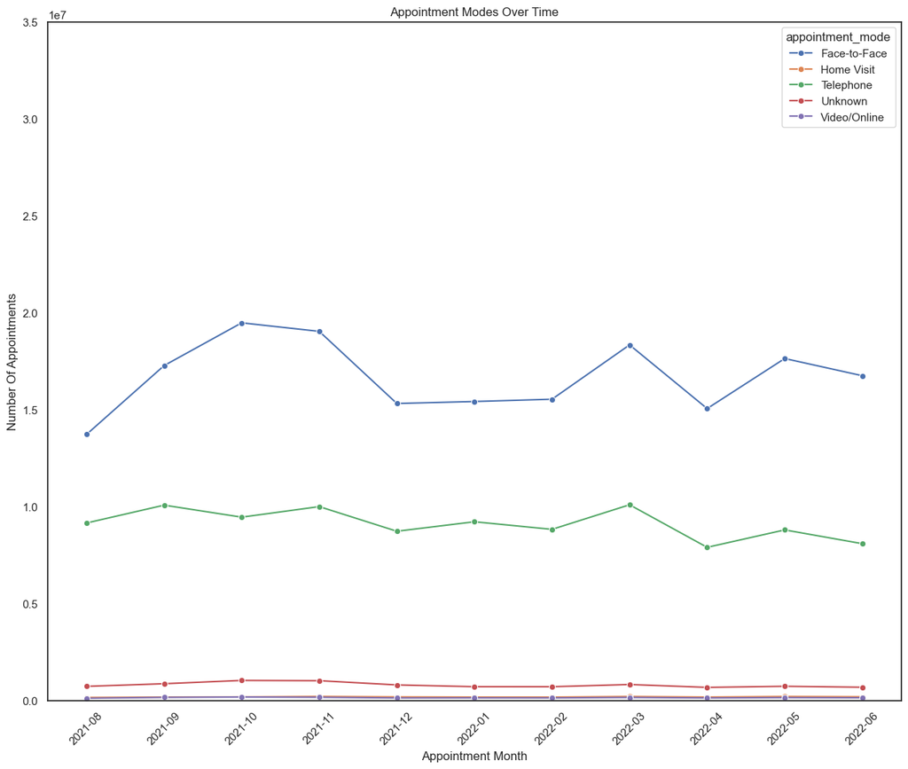

```python
# Create a lineplot to answer the question
sns.lineplot(
    data = mode_monthly,
    x = 'appointment_month',
    y = 'count_of_appointments',
    hue = 'appointment_mode',
    marker = 'o',
)

plt.title('Appointment Modes Over Time')
plt.xlabel('Appointment Month')
plt.ylabel('Number Of Appointments')
plt.xticks(rotation = 45)
plt.ylim(0, 3.5e7)
plt.show()
```

There is not a dramatic shift in the proportion or difference between Face-to-Face and Telephone appointments.

Face to Face leads several million appointments over Telephone calls.

By observing the peaks in the two most common appointment modes (Face-to-Face and Telephone), the months with the highest overall appointments are:

- October 2021
- November 2021
- March 2022

### ❓ Are there any trends in time between booking and appointment?

```python
# Create a variable linking the time between booking to appointment day.
wait_times = (
    ar_agg.groupby(['appointment_month','time_between_book_and_appointment'])
    ['count_of_appointments']
    .sum()
    .reset_index()
)
```

```python
# Create an order for the hue to follow
desired_order = ['Same Day','2 to 7 Days','8  to 14 Days','1 Day','15  to 21 Days','22  to 28 Days','More than 28 Days','Unknown / Data Quality']
```

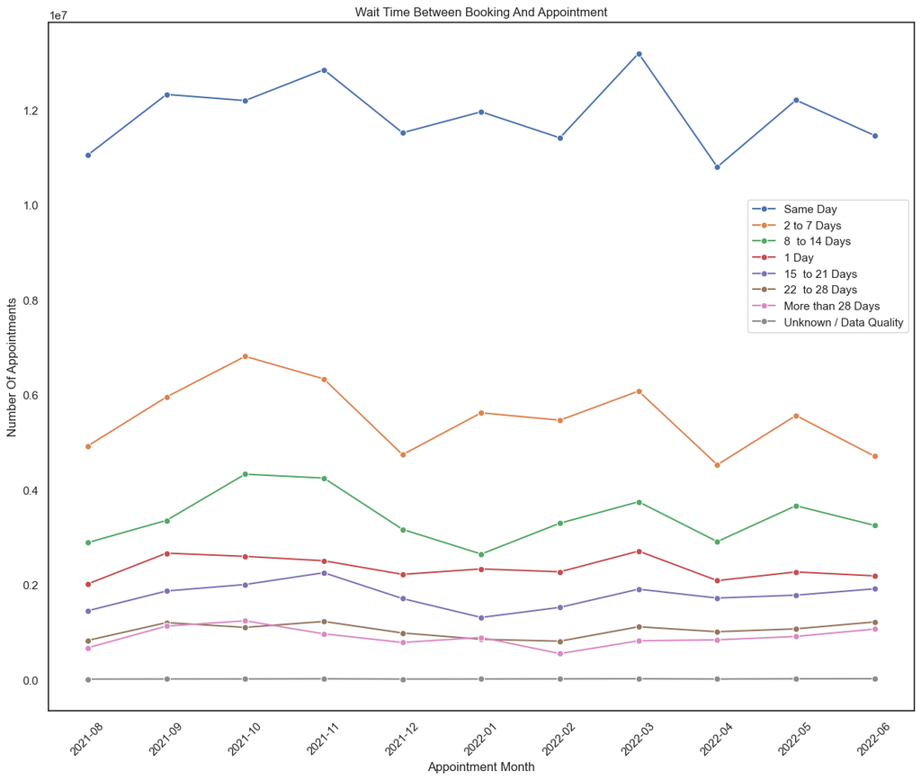

```python
# Create a line plot to display the trend
sns.lineplot(
    data = wait_times,
    x = 'appointment_month',
    y = 'count_of_appointments',
    hue = 'time_between_book_and_appointment',
    hue_order = desired_order,
    marker = 'o'
)

plt.title('Wait Time Between Booking And Appointment')
plt.xlabel('Appointment Month')
plt.ylabel('Number Of Appointments')
plt.xticks(rotation = 45)
plt.legend(bbox_to_anchor=(1.00,0.75))
plt.show()
```

The vast majority of appointments are booked for either the same day or 2 to 7 days, which is a postivie indicator for quick access to appointments.

The rise and fall of these two categories rise and fall in sync with the overall appointment volume suggesting influence by patient demand.

There is no indication of a growing number of longer wait times.

### ❓ How do the various service settings compare?

```python
# Use the nc DataFrame to determine how service settings compare
nc.head()
```

|  | appointment_date | icb_ons_code | sub_icb_location_name | service_setting | context_type | national_category | count_of_appointments | appointment_month |
| --- | --- | --- | --- | --- | --- | --- | --- | --- |
| 0 | 2021-08-02 | E54000050 | NHS North East and North Cumbria ICB - 00L | Primary Care Network | Care Related Encounter | Patient contact during Care Home Round | 3 | 2021-08 |
| 1 | 2021-08-02 | E54000050 | NHS North East and North Cumbria ICB - 00L | Other | Care Related Encounter | Planned Clinics | 7 | 2021-08 |
| 2 | 2021-08-02 | E54000050 | NHS North East and North Cumbria ICB - 00L | General Practice | Care Related Encounter | Home Visit | 79 | 2021-08 |
| 3 | 2021-08-02 | E54000050 | NHS North East and North Cumbria ICB - 00L | General Practice | Care Related Encounter | General Consultation Acute | 725 | 2021-08 |
| 4 | 2021-08-02 | E54000050 | NHS North East and North Cumbria ICB - 00L | General Practice | Care Related Encounter | Structured Medication Review | 2 | 2021-08 |

```python
# Create a new DataFrame grouping the number of appointments by its service setting for each month
nc_monthly_service_appts = (
    nc.groupby(['appointment_month','service_setting'])['count_of_appointments']
    .sum()
    .reset_index()
)
# View the DataFrame.
nc_monthly_service_appts.head()
```

|  | appointment_month | service_setting | count_of_appointments |
| --- | --- | --- | --- |
| 0 | 2021-08 | Extended Access Provision | 160927 |
| 1 | 2021-08 | General Practice | 21575852 |
| 2 | 2021-08 | Other | 449101 |
| 3 | 2021-08 | Primary Care Network | 432448 |
| 4 | 2021-08 | Unmapped | 1233843 |

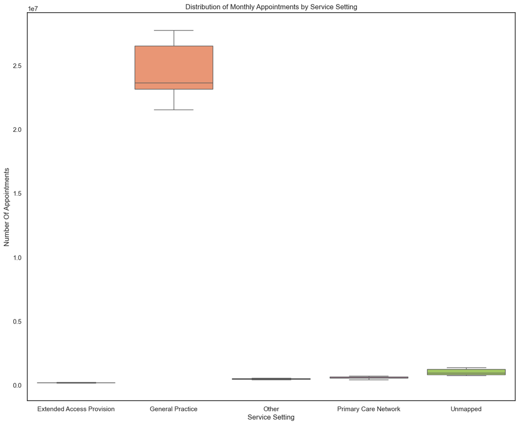

```python
# Create a box plot in Seaborn based on the new dataframe indicating the service setting against the number of appointments.
sns.boxplot(
    data = nc_monthly_service_appts,
    x = 'service_setting',
    y = 'count_of_appointments',
    palette = 'Set2'
)

plt.title('Distribution of Monthly Appointments by Service Setting')
plt.xlabel('Service Setting')
plt.ylabel('Number Of Appointments')
plt.show()
```

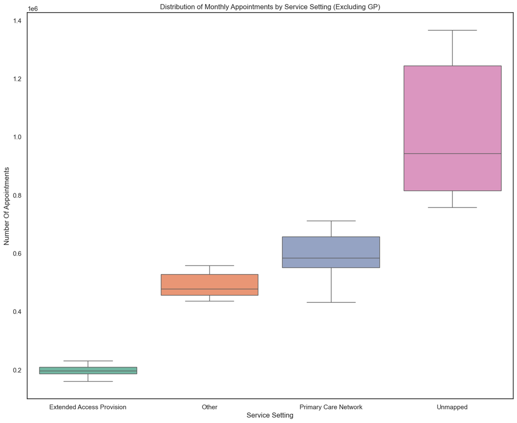

```python
# Create a boxplot in Seaborn where you concentrate on all the service settings, excluding GP visits.
filtered_service_nc = nc_monthly_service_appts[nc_monthly_service_appts['service_setting'] != 'General Practice']

sns.boxplot(
    data = filtered_service_nc,
    x = 'service_setting',
    y = 'count_of_appointments',
    palette = 'Set2'
)

plt.title('Distribution of Monthly Appointments by Service Setting (Excluding GP)')
plt.xlabel('Service Setting')
plt.ylabel('Number Of Appointments')
plt.show()
```

There is overwhelming dominance of General Practice appointments. All others contribute a minor volume of appointments to the total.

Followed by the unmapped appointments, indicating a considerable portion of the data has not either been mapped correctly or there are data quality issues. This could be further investigated to determine what those appointments entail, and how to prevent this issue from the future.

## 🔍 Summary of Findings and Recommendations

### 🧠 Key Findings:

[output not shown]

### ✅ Recommendations:

```
- Increase staffing during high-demand months by increasing base level or employing temporary staff during surges.
- Shift appropriate tasks to nurses and support staff to reduce strain on GPs.
- Improve appointment scheduling to reduce appointment turnovers of more than 7 days.
- Monitor utilisation metrics monthly to assess the demand on NHS services.
- Popular hashtags reflect public interest in NHS job opportunities, and the growing role of digital health which could help relieve pressure on NHS services, by decreasing the need for certain appointments.
```

### ⚠️ Data Limitations:

```
- Twitter data does not contain the dates of tweets which makes it harder to pinpoint when they were most popular.
- We do not know staffing numbers within the networks which makes minimum staffing numbers harder to match with current utilisation - thus making it difficult to determine if there has been adequate staff in the networks.
```

**Has there been adequate staffing and capacity in the networks?**

> Staff utilisation regularly exceeded 80% during peak months, indicating the sytem was operating close to full capacity. This suggests staffing levels may not have been sufficient enough to handle demand without strain. However, due to the absence of staffing headcount data, we cannot confirm if there was adequacy across the networks.

**What was the actual utilisation of resources?**